# test-my-environment

1 Jupyter notebooks

2 Instructions

3 `matplotlib`

4 `seaborn`

5 `numpy`

6 `pandas`

7 `folium`

8 `sklearn`

9 `Missingno`

10 `pivottablejs`

11 `pandas_profiling`

12 `ipywidgets`

13 `tqdm`

14 `mpld3`

# Jupyter notebooks

If you are new to Jupyter notebooks, take a look around! There is a `user interface tour` under the `help` dropdown as well as some other useful links.

# Instructions

- Try to run all the cells in this notebook.
- If you get errors, still try to run the other sections. There are limited dependencies.
- At least run all of the cells with `import` in the them.
- The html file in this directory, `test-my-environment.html` is what your notebook should look like if it runs successfully.
- Take note of which packages don't load and feel free to post in the slack channel relevant to your OS (#macos, #linux, or #windows) the errors you are getting.
- If you get errors, make sure to sign up for an account on https://notebooks.azure.com/ (see e-mail and repo README for more instructions)

# `matplotlib`

You want to issue the first command `%matplotlib inline` typically before all other commands.

```python
%matplotlib inline
%config InlineBackend.figure_format='retina'

from matplotlib import pyplot as plt
```

Assuming that worked, let's see if we can plot something and see it in the notebook:

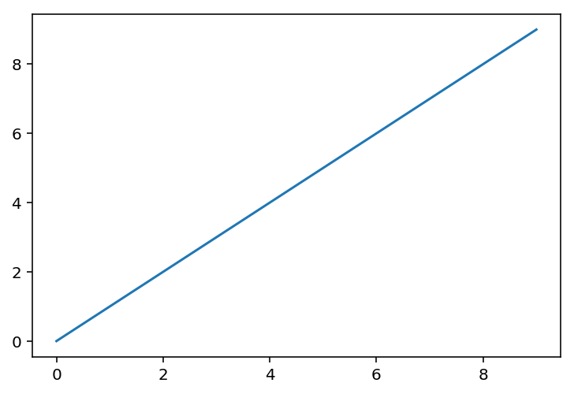

```python
plt.plot(range(10),range(10));
```

It won't be very exciting but you should now see a figure with a line drawn above ^^

# `seaborn`

`seaborn` replaces a lot of ugly defaults in `matplotlib` and makes plotting nice figures easier.

```python
import seaborn as sns
sns.set_context("poster", font_scale=1.3)
```

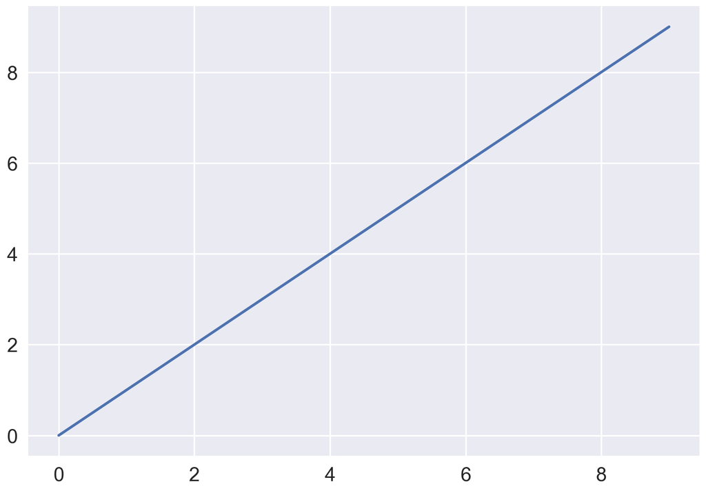

```python
sns.plt.plot(range(10), range(10));
```

You should now see the same figure as with matplotlib but formatted somewhat more nicely.

# `numpy`

`numpy` helps us do math good and other stuff good too. Try importing it.

```python
import numpy as np
```

Let's try generating some random numbers.

```python
np.random.rand(10)
```

```
array([ 0.96569821,  0.36631486,  0.67581861,  0.64602625,  0.85646926,
        0.88595065,  0.11228483,  0.63085252,  0.72407336,  0.25368692])
```

The above should produce an [*array*](https://docs.scipy.org/doc/numpy/user/quickstart.html) with 10 random numbers.

```python
import os, sys
import warnings
warnings.filterwarnings('ignore')
```

# `pandas`

We will be using `pandas` wrangle our data.

```python
import pandas as pd
```

```python
data = pd.DataFrame([[1,2,3],[4,5,6]],
                    columns=['a','b','c'],
                    index=['one','two'])
data.head()
```

|  | a | b | c |
| --- | --- | --- | --- |
| one | 1 | 2 | 3 |
| two | 4 | 5 | 6 |

# `folium`

We will be looking at some data on maps so let's make sure folium works.

```python
import folium
```

```python
map = folium.Map(location=[45.528163,-122.6643382], zoom_start=16,
                     width=1200, height=600)
```

```python
map
```

[interactive chart not shown]

You should now see above a map of where you are **right** now... creepy. Okay, actually, it's only showing where you are if you're already at PyCon!

# `sklearn`

We will use the `sklearn` package for doing some more advanced exploration of high-dimensional data.

```python
from sklearn import datasets
```

```python
iris_data = datasets.load_iris()
```

```python
df = pd.DataFrame(iris_data.data, columns=iris_data.feature_names)
df['target'] = iris_data.target
```

```python
df.head()
```

|  | sepal length (cm) | sepal width (cm) | petal length (cm) | petal width (cm) | target |
| --- | --- | --- | --- | --- | --- |
| 0 | 5.1 | 3.5 | 1.4 | 0.2 | 0 |
| 1 | 4.9 | 3.0 | 1.4 | 0.2 | 0 |
| 2 | 4.7 | 3.2 | 1.3 | 0.2 | 0 |
| 3 | 4.6 | 3.1 | 1.5 | 0.2 | 0 |
| 4 | 5.0 | 3.6 | 1.4 | 0.2 | 0 |

# `Missingno`

We will use the [`missingno`](https://github.com/ResidentMario/missingno) package to assess missing data.

```python
import missingno as msno
```

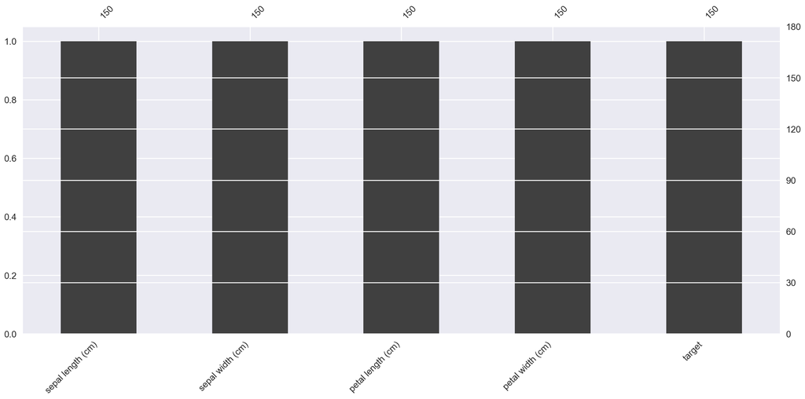

```python
msno.bar(df)
```

You should see a bar plot above. Don't worry about what it means right now!

# `pivottablejs`

```python
import pivottablejs
```

```python
pivottablejs.pivot_ui(df)
```

[interactive chart not shown]

# `pandas_profiling`

```python
import pandas_profiling
```

Overview

Dataset info

| Number of variables | 5 |
| --- | --- |
| Number of observations | 150 |
| Total Missing (%) | 0.0% |
| Total size in memory | 5.9 KiB |
| Average record size in memory | 40.5 B |

Variables types

| Numeric | 3 |
| --- | --- |
| Categorical | 0 |
| Date | 0 |
| Text (Unique) | 0 |
| Rejected | 2 |

Warnings

- `petal width (cm)` is highly correlated with `petal length (cm)` (ρ = 0.96276) Rejected

- `target` is highly correlated with `petal width (cm)` (ρ = 0.95646) Rejected

Variables

petal length (cm)  
Numeric

| Distinct count | 43 |
| --- | --- |
| Unique (%) | 28.7% |
| Missing (%) | 0.0% |
| Missing (n) | 0 |
| Infinite (%) | 0.0% |
| Infinite (n) | 0 |

| Mean | 3.7587 |
| --- | --- |
| Minimum | 1 |
| Maximum | 6.9 |
| Zeros (%) | 0.0% |

Toggle details

**Statistics**

Quantile statistics

| Minimum | 1 |
| --- | --- |
| 5-th percentile | 1.3 |
| Q1 | 1.6 |
| Median | 4.35 |
| Q3 | 5.1 |
| 95-th percentile | 6.1 |
| Maximum | 6.9 |
| Range | 5.9 |
| Interquartile range | 3.5 |

Descriptive statistics

| Standard deviation | 1.7644 |
| --- | --- |
| Coef of variation | 0.46943 |
| Kurtosis | -1.4019 |
| Mean | 3.7587 |
| MAD | 1.5619 |
| Skewness | -0.27446 |
| Sum | 563.8 |
| Variance | 3.1132 |
| Memory size | 1.2 KiB |

**Histogram**

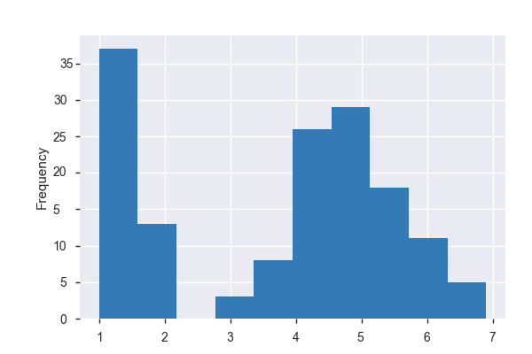

**Common Values**

| Value | Count | Frequency (%) |  |
| --- | --- | --- | --- |
| 1.5 | 14 | 9.3% |  |
| 1.4 | 12 | 8.0% |  |
| 5.1 | 8 | 5.3% |  |
| 4.5 | 8 | 5.3% |  |
| 1.3 | 7 | 4.7% |  |
| 1.6 | 7 | 4.7% |  |
| 5.6 | 6 | 4.0% |  |
| 4.0 | 5 | 3.3% |  |
| 4.9 | 5 | 3.3% |  |
| 4.7 | 5 | 3.3% |  |
| Other values (33) | 73 | 48.7% |  |

**Extreme Values**

Minimum 5 values

| Value | Count | Frequency (%) |  |
| --- | --- | --- | --- |
| 1.0 | 1 | 0.7% |  |
| 1.1 | 1 | 0.7% |  |
| 1.2 | 2 | 1.3% |  |
| 1.3 | 7 | 4.7% |  |
| 1.4 | 12 | 8.0% |  |

Maximum 5 values

| Value | Count | Frequency (%) |  |
| --- | --- | --- | --- |
| 6.3 | 1 | 0.7% |  |
| 6.4 | 1 | 0.7% |  |
| 6.6 | 1 | 0.7% |  |
| 6.7 | 2 | 1.3% |  |
| 6.9 | 1 | 0.7% |  |

`petal width (cm)`  
Highly correlated

*This variable is highly correlated with `petal length (cm)` and should be ignored for analysis*

| Correlation | 0.96276 |
| --- | --- |

sepal length (cm)  
Numeric

| Distinct count | 35 |
| --- | --- |
| Unique (%) | 23.3% |
| Missing (%) | 0.0% |
| Missing (n) | 0 |
| Infinite (%) | 0.0% |
| Infinite (n) | 0 |

| Mean | 5.8433 |
| --- | --- |
| Minimum | 4.3 |
| Maximum | 7.9 |
| Zeros (%) | 0.0% |

Toggle details

**Statistics**

Quantile statistics

| Minimum | 4.3 |
| --- | --- |
| 5-th percentile | 4.6 |
| Q1 | 5.1 |
| Median | 5.8 |
| Q3 | 6.4 |
| 95-th percentile | 7.255 |
| Maximum | 7.9 |
| Range | 3.6 |
| Interquartile range | 1.3 |

Descriptive statistics

| Standard deviation | 0.82807 |
| --- | --- |
| Coef of variation | 0.14171 |
| Kurtosis | -0.55206 |
| Mean | 5.8433 |
| MAD | 0.68756 |
| Skewness | 0.31491 |
| Sum | 876.5 |
| Variance | 0.68569 |
| Memory size | 1.2 KiB |

**Histogram**

[figure not shown]

**Common Values**

| Value | Count | Frequency (%) |  |
| --- | --- | --- | --- |
| 5.0 | 10 | 6.7% |  |
| 6.3 | 9 | 6.0% |  |
| 5.1 | 9 | 6.0% |  |
| 6.7 | 8 | 5.3% |  |
| 5.7 | 8 | 5.3% |  |
| 5.5 | 7 | 4.7% |  |
| 5.8 | 7 | 4.7% |  |
| 6.4 | 7 | 4.7% |  |
| 6.0 | 6 | 4.0% |  |
| 4.9 | 6 | 4.0% |  |
| Other values (25) | 73 | 48.7% |  |

**Extreme Values**

Minimum 5 values

| Value | Count | Frequency (%) |  |
| --- | --- | --- | --- |
| 4.3 | 1 | 0.7% |  |
| 4.4 | 3 | 2.0% |  |
| 4.5 | 1 | 0.7% |  |
| 4.6 | 4 | 2.7% |  |
| 4.7 | 2 | 1.3% |  |

Maximum 5 values

| Value | Count | Frequency (%) |  |
| --- | --- | --- | --- |
| 7.3 | 1 | 0.7% |  |
| 7.4 | 1 | 0.7% |  |
| 7.6 | 1 | 0.7% |  |
| 7.7 | 4 | 2.7% |  |
| 7.9 | 1 | 0.7% |  |

sepal width (cm)  
Numeric

| Distinct count | 23 |
| --- | --- |
| Unique (%) | 15.3% |
| Missing (%) | 0.0% |
| Missing (n) | 0 |
| Infinite (%) | 0.0% |
| Infinite (n) | 0 |

| Mean | 3.054 |
| --- | --- |
| Minimum | 2 |
| Maximum | 4.4 |
| Zeros (%) | 0.0% |

Toggle details

**Statistics**

Quantile statistics

| Minimum | 2 |
| --- | --- |
| 5-th percentile | 2.345 |
| Q1 | 2.8 |
| Median | 3 |
| Q3 | 3.3 |
| 95-th percentile | 3.8 |
| Maximum | 4.4 |
| Range | 2.4 |
| Interquartile range | 0.5 |

Descriptive statistics

| Standard deviation | 0.43359 |
| --- | --- |
| Coef of variation | 0.14198 |
| Kurtosis | 0.29078 |
| Mean | 3.054 |
| MAD | 0.33309 |
| Skewness | 0.33405 |
| Sum | 458.1 |
| Variance | 0.188 |
| Memory size | 1.2 KiB |

**Histogram**

[figure not shown]

**Common Values**

| Value | Count | Frequency (%) |  |
| --- | --- | --- | --- |
| 3.0 | 26 | 17.3% |  |
| 2.8 | 14 | 9.3% |  |
| 3.2 | 13 | 8.7% |  |
| 3.4 | 12 | 8.0% |  |
| 3.1 | 12 | 8.0% |  |
| 2.9 | 10 | 6.7% |  |
| 2.7 | 9 | 6.0% |  |
| 2.5 | 8 | 5.3% |  |
| 3.5 | 6 | 4.0% |  |
| 3.8 | 6 | 4.0% |  |
| Other values (13) | 34 | 22.7% |  |

**Extreme Values**

Minimum 5 values

| Value | Count | Frequency (%) |  |
| --- | --- | --- | --- |
| 2.0 | 1 | 0.7% |  |
| 2.2 | 3 | 2.0% |  |
| 2.3 | 4 | 2.7% |  |
| 2.4 | 3 | 2.0% |  |
| 2.5 | 8 | 5.3% |  |

Maximum 5 values

| Value | Count | Frequency (%) |  |
| --- | --- | --- | --- |
| 3.9 | 2 | 1.3% |  |
| 4.0 | 1 | 0.7% |  |
| 4.1 | 1 | 0.7% |  |
| 4.2 | 1 | 0.7% |  |
| 4.4 | 1 | 0.7% |  |

`target`  
Highly correlated

*This variable is highly correlated with `petal width (cm)` and should be ignored for analysis*

| Correlation | 0.95646 |
| --- | --- |

Sample

|  | sepal length (cm) | sepal width (cm) | petal length (cm) | petal width (cm) | target |
| --- | --- | --- | --- | --- | --- |
| 0 | 5.1 | 3.5 | 1.4 | 0.2 | 0 |
| 1 | 4.9 | 3.0 | 1.4 | 0.2 | 0 |
| 2 | 4.7 | 3.2 | 1.3 | 0.2 | 0 |
| 3 | 4.6 | 3.1 | 1.5 | 0.2 | 0 |
| 4 | 5.0 | 3.6 | 1.4 | 0.2 | 0 |

```python
pandas_profiling.ProfileReport(df)
```

# `ipywidgets`

We can use `ipywidgits` to create interactive outputs. Before being able to use `ipywidgets` you need to have already run the following from the command line (as was instructed in the repo README):

`jupyter nbextension enable --py --sys-prefix widgetsnbextension`

```python
import ipywidgets as widgets
```

```python
slider = widgets.IntSlider(min=0, max=10,value=5, description='Line width:')
```

```python
def plot(x, y, linewidth=1):
    fig, ax = plt.subplots(figsize=(8,6))
    plt.plot(x, y, linewidth=linewidth)
    plt.close()
    return fig
```

```python
widgets.interact(plot, x=widgets.fixed(range(10)),
                 y=widgets.fixed(range(10)),
                 linewidth=slider);
```

# `tqdm`

`tqdm` is nice for monitoring how long your `for` loops are taking.

```python
from tqdm import tqdm
```

```python
test = []
for i in tqdm(range(10000000)):
    test.append(i)
```

```python
clear test
```

```python
import mpld3
```

# `mpld3`

`mpld3` allows for some nice interactive functionality using D3. We will just run an [example](https://mpld3.github.io/examples/html_tooltips.html) from the `mpld3` repo.

```python
import mpld3
from mpld3 import plugins
```

```python
mpld3.enable_notebook()
```

```python
fig, ax = plt.subplots()
ax.grid(True, alpha=0.3)

N = 50
df = pd.DataFrame(index=range(N))
df['x'] = np.random.randn(N)
df['y'] = np.random.randn(N)
df['z'] = np.random.randn(N)

labels = []
for i in range(N):
    label = df.ix[[i], :].T
    label.columns = ['Row {0}'.format(i)]
    # .to_html() is unicode; so make leading 'u' go away with str()
    labels.append(str(label.to_html()))

points = ax.plot(df.x, df.y, 'o', color='b',
                 mec='k', ms=15, mew=1, alpha=.6)

ax.set_xlabel('x')
ax.set_ylabel('y')
ax.set_title('HTML tooltips', size=20)

tooltip = plugins.PointHTMLTooltip(points[0], labels,
                                   voffset=10, hoffset=10)
plugins.connect(fig, tooltip)
```

[output not shown]